# Ordinal Analysis (Universe #3)

Author

Simmons & Girard

Published

May 10, 2026

# 1. Setup

Libraries

```r
# Load Packages
library(tidyverse)
library(simhelpers)
library(knitr)
library(kableExtra)
library(gt)
library(paletteer)
# ---
```

{gt} styling template

```r
#{gt} Theme --
my_gt_theme <- function(gt_object){
  gt_object |>
  opt_table_font(
    font = list(
      google_font(name = "Arial"), # Preferred
      "serif")) |>
  tab_options(
    table.border.top.style = "none",
    table.border.bottom.style = "solid",
    table.border.bottom.width = px(2),
    column_labels.border.top.style = "solid",
    column_labels.border.top.width = px(2),
    column_labels.border.bottom.style = "solid",
    column_labels.border.bottom.width = px(1),
    table_body.border.bottom.style = "solid",
    table_body.border.bottom.width = px(2)
  )
}
# ----
```

# 2. Data Wrangling

## 2.1 Directory & Loading Data

```r
DIR <-  "~/Documents/Github/MastersThesis/iccs/data/universe_3/"
```

```r
nest_rds_files <- function(data_df, filename_col, directory_path) {
  # 1. Ensure the directory path ends with a slash for file path construction
  dir <- ifelse(grepl("/$", directory_path), directory_path, paste0(directory_path, "/"))

  # 2. Create the new nested column
  # We use sym() to handle the column name if passed as a string
  result_df <- data_df %>%
    mutate(result = map(!!sym(filename_col), function(fname) {
      file_path <- paste0(dir, fname)

      # Check if file exists to avoid crashing the whole loop
      if (file.exists(file_path)) {
        return(readRDS(file_path))
      } else {
        warning(paste("File not found:", file_path))
        return(NULL)
      }
    }))

  return(result_df)
}
```

## 2.2 Data Wrangling

**In the ordinal case, the parameter grid of conditions is as follows and add each file to its condition**

The complete simulations required a post-hoc re-run including the use of {glmmTMB} alongside of {lme4} for linear mixed model fitting. This was obtained in `dat_nest2`

```r
# Paramter Grid
design_factors <- list(
n_raters = c(3,12,24),
n_objects = c(10,50,100),
target_icc = c(0.40,0.60,0.80),
k_category = c(3,5,7),
e_category = c(TRUE,FALSE),
# 1 = equal category prevalence, #0 = unequal linear decay prevalence
icc_type = c(1,2,3,4)
)
# Expand grid and
# Join each data file to its condition
params <- expand_grid( !!!design_factors) |>
    mutate(
    seed = 03122026 + 17 * 1:n(), #set seed for each row,
    condition = 1:n() * 1,
    filename = paste0("ordinal_UThree_",condition,"_",seed,".rds"))

dat_nest <- nest_rds_files(params, "filename", DIR)

params2 <- params |>
  select(-filename) |>
  mutate(filename = paste0(
    "ordinal_onlyglmmtmb_",condition,"_",seed,".rds"))


ODIR <- "~/Documents/Github/MastersThesis/iccs/data/"
#glmmtmb linear fits only
dat_nest2 <- nest_rds_files(params2, "filename", ODIR)

#head(params)
#head(params2)
```

Here, I unnested the entire simulation sets to obtain the full data

```r
dat <- dat_nest |> unnest(result)
dat2 <- dat_nest2 |> unnest(result)

# Delete nested object
rm(dat_nest) # no longer neaded
rm(dat_nest2 ) #no longer needed

# Set each condition of the simulations as factors
conds <- c("n_raters", "n_objects", "k_category", "icc", "e_category", "icc_type", "condition", "method")
dat <- dat |>
  mutate(across(.cols = all_of(conds), .fns = as.factor))
dat2 <- dat2 |>
  mutate(across(.cols = all_of(conds), .fns = as.factor))
```

Critically, datasets were subsetted so that each g_icc() is matched with its corresponding data generating variance hyper-parameters

```r
dat_full <- bind_rows(dat, dat2) |>
  select(-seed, -filename) |>
  filter(
    (icc_type == 1 & icc == "ICC(A,1)") |
    (icc_type == 2 & icc == "ICC(A,k)") |
    (icc_type == 3 & icc == "ICC(C,1)") |
    (icc_type == 4 & icc == "ICC(C,k)"))

# Clean up
rm(dat, dat2)
```

# 2. Descriptives

# 2.1 Simulation Error Rates

First, let’s check how many conditions obtained errors. Here, I considered a simulation to *fail* whenever there was a “message”, “warning”, or “error” associated with any one model fit in {lm} for ANOVA, and {lme4}, {glmmTMB}, and {ordinal} for LMMs.

Here: Errors are conditional on ICC type and method

```r
errors <- dat_full |>
  mutate(
    across(.cols = c("message","warning","error"), .fns = as.logical)) |>
  mutate( is_invalid = message | warning | error) |>
  summarise(
    total_trials = n(),
    invalid_trials = sum(is_invalid, na.rm = TRUE),
    percent_error = mean(is_invalid, na.rm = TRUE) * 100,
    .by = c(method,icc)
  ) |>
  arrange(match(method, c("icc","icc_glmmtmb", "g_icc","aov_icc"))
  ) |>
  arrange(icc) |>
  mutate(method = fct_recode(method,
  "LMM {lme4}" = "icc",
  "LMM {glmmtmb}" = "icc_glmmtmb",
  "GLMM {ordinal}" = "g_icc",
  "ANOVA {lm}" = "aov_icc",
  ))
```

Print {gt} Table

```r
errors |>
  gt() |>
  my_gt_theme() |>
  tab_header(
    title = "Simulation Failure Rates (Ordinal Data)",
    subtitle = "Comparing Across Method and ICC-Type"
  ) |>
  # Format the percentage column (adds the % sign and rounds to 1 decimal)
  fmt_percent(
    columns = percent_error,
    scale_values = FALSE,
    decimals = 2
  ) |>
  # Make the column names look professional
  cols_label(
    method = "Method",
    icc = "ICC Type",
    total_trials = "Total Trials",
    invalid_trials = "Invalid Trials",
    percent_error = "Percent Error"
  ) |>
  data_color(
    column = icc,
    target_columns = everything(),
    method = "factor",
    palette = "RColorBrewer::Blues"
  )
```

Simulation Failure Rates (Ordinal Data)

Comparing Across Method and ICC-Type

| Method | ICC Type | Total Trials | Invalid Trials | Percent Error |
| --- | --- | --- | --- | --- |
| LMM {lme4} | ICC(A,1) | 162000 | 7264 | 4.48% |
| LMM {glmmtmb} | ICC(A,1) | 162000 | 117 | 0.07% |
| GLMM {ordinal} | ICC(A,1) | 162000 | 189 | 0.12% |
| ANOVA {lm} | ICC(A,1) | 162000 | 0 | 0.00% |
| LMM {lme4} | ICC(A,k) | 162000 | 34918 | 21.55% |
| LMM {glmmtmb} | ICC(A,k) | 162000 | 405 | 0.25% |
| GLMM {ordinal} | ICC(A,k) | 162000 | 5 | 0.00% |
| ANOVA {lm} | ICC(A,k) | 162000 | 0 | 0.00% |
| LMM {lme4} | ICC(C,1) | 162000 | 9117 | 5.63% |
| LMM {glmmtmb} | ICC(C,1) | 162000 | 50 | 0.03% |
| GLMM {ordinal} | ICC(C,1) | 162000 | 44 | 0.03% |
| ANOVA {lm} | ICC(C,1) | 162000 | 0 | 0.00% |
| LMM {lme4} | ICC(C,k) | 162000 | 35774 | 22.08% |
| LMM {glmmtmb} | ICC(C,k) | 162000 | 389 | 0.24% |
| GLMM {ordinal} | ICC(C,k) | 162000 | 4 | 0.00% |
| ANOVA {lm} | ICC(C,k) | 162000 | 0 | 0.00% |

# 2.2 Negative ICC rates

Negative ICCs conditional on ICC type and method

```r
negative_summary <- dat_full |>
  summarise(
    total_trials = n(),
    negative_count = sum(estimate < 0, na.rm = TRUE),
    .by = c(method,icc),
    negative_pct = mean(estimate < 0, na.rm = TRUE)
  ) |>
  arrange(match(method, c("icc","icc_glmmtmb", "g_icc","aov_icc"))
  ) |>
  arrange(icc) |>
  mutate(method = fct_recode(method,
  "LMM {lme4}" = "icc",
  "LMM {glmmtmb}" = "icc_glmmtmb",
  "GLMM {ordinal}" = "g_icc",
  "ANOVA {lm}" = "aov_icc",
  ))

negative_summary |>
  gt() |>
  my_gt_theme() |>
  tab_header(
    title = "Negative ICC Rates (Ordinal Data)",
    subtitle = "Comparing Across Method and ICC-Type"
  ) |>
  # Format the percentage column (adds the % sign and rounds to 1 decimal)
  fmt_percent(
    columns = negative_pct,
    scale_values = FALSE,
    decimals = 2
  ) |>
  # Make the column names look professional
  cols_label(
    method = "Method",
    icc = "ICC Type",
    total_trials = "Total Trials",
    negative_count = "Trials Negative ICC",
    negative_pct = "Percent Negative"
  ) |>
  data_color(
    column = icc,
    target_columns = everything(),
    method = "factor",
    palette = "RColorBrewer::Blues"
  )
```

Negative ICC Rates (Ordinal Data)

Comparing Across Method and ICC-Type

| Method | ICC Type | Total Trials | Trials Negative ICC | Percent Negative |
| --- | --- | --- | --- | --- |
| LMM {lme4} | ICC(A,1) | 162000 | 0 | 0.00% |
| LMM {glmmtmb} | ICC(A,1) | 162000 | 0 | 0.00% |
| GLMM {ordinal} | ICC(A,1) | 162000 | 0 | 0.00% |
| ANOVA {lm} | ICC(A,1) | 162000 | 7035 | 0.04% |
| LMM {lme4} | ICC(A,k) | 162000 | 0 | 0.00% |
| LMM {glmmtmb} | ICC(A,k) | 162000 | 0 | 0.00% |
| GLMM {ordinal} | ICC(A,k) | 162000 | 0 | 0.00% |
| ANOVA {lm} | ICC(A,k) | 162000 | 31434 | 0.19% |
| LMM {lme4} | ICC(C,1) | 162000 | 0 | 0.00% |
| LMM {glmmtmb} | ICC(C,1) | 162000 | 0 | 0.00% |
| GLMM {ordinal} | ICC(C,1) | 162000 | 0 | 0.00% |
| ANOVA {lm} | ICC(C,1) | 162000 | 8790 | 0.05% |
| LMM {lme4} | ICC(C,k) | 162000 | 0 | 0.00% |
| LMM {glmmtmb} | ICC(C,k) | 162000 | 0 | 0.00% |
| GLMM {ordinal} | ICC(C,k) | 162000 | 0 | 0.00% |
| ANOVA {lm} | ICC(C,k) | 162000 | 32448 | 0.20% |

# 3. Performance Measures for Point Estimators

Here, we consider performance measures for point estimators for each of the 162 ordinal conditions.

We obtain, for each condition and measure (ICC, Generalized ICC, and AOV_ICC): - Bias (defined as “Mean absolute error” by Oest & Girard, Miratrix & Pustejovsky) - Bias (defined by Muthen & Muthen) - Standard Errors (i.e., standard deviation of replication distribution) - Root Mean Squared Error (RMSE)

```r
bias <- dat_full |>
  #some NA (4) in g-ICC(C,k) and negative aov_iccs |>
  filter(estimate >= 0 )|>
  summarize(
    simhelpers::calc_absolute(
      estimates = estimate, true_param = target_icc,
      criteria = c("bias","stddev","rmse")
    ),
    .by = c(n_raters, n_objects, target_icc, icc, k_category, e_category, icc_type, condition, method)
  ) |>
  mutate(bias2 = bias/target_icc) |> #Muthen&Muthen
  mutate(bias2_mcse = bias_mcse/target_icc) |> #Muthen&Muthen
  mutate(Method = fct_recode(method,
    "LMM {lme4}" = "icc",
    "LMM {glmmtmb}" = "icc_glmmtmb",
    "GLMM {ordinal}" = "g_icc",
    "ANOVA {lm}" = "aov_icc", )
  ) |>
  mutate(Objects = n_objects) |>
  mutate(`Target ICC` = target_icc) |>
  mutate(`Category Equality` = e_category)
```

Plot functions

```r
my_geom <- list(
  geom_point(position = position_dodge(width = 0.3)),
  geom_line(position = position_dodge(width = 0.3)),
  geom_errorbar( aes( ymin = bias - 1.96*bias_mcse,
                      ymax = bias + 1.96*bias_mcse ),
                 position = position_dodge( width=0.3),
                 width = 0 ),
  geom_hline( yintercept = 0 ),
  theme_minimal()
)

my_geom2 <- list(
  geom_point(position = position_dodge(width = 0.3)),
  geom_line(position = position_dodge(width = 0.3)),
  geom_errorbar( aes( ymin = bias2 - 1.96*bias2_mcse,
                      ymax = bias2 + 1.96*bias2_mcse ),
                 position = position_dodge( width=0.3),
                 width = 0 ),
  geom_hline( yintercept = 0),
  geom_hline(yintercept = -0.10, color = "red", linetype = "dashed" ),
  geom_hline(yintercept = 0.10, color = "red", linetype = "dashed" ),
  theme_minimal()
)

my_geom_rmse <- list(
  geom_point(position = position_dodge(width = 0.3)),
  geom_line(position = position_dodge(width = 0.3)),
  geom_errorbar( aes( ymin = rmse - 1.96*rmse_mcse,
                      ymax = rmse + 1.96*rmse_mcse ),
                 position = position_dodge( width=0.3),
                 width = 0 ),
  geom_hline( yintercept = 0),
  theme_minimal()
)

labs_by_type <- list(
labs(y = "Mean MAE Bias (±1 SD)"),
labs(y = "Mean MM Bias (±1 SD)"),
labs(y = "Mean RMSE Bias (±1 SD)")
)



plot_simulation_bias <- function(data, x_var, y_var, col_var, facet_row, facet_col, my_geoms, plot_labs, title = "Simulation Bias") {

  ggplot(data, aes(x = {{x_var}},
                   y = {{y_var}},
                   col = {{col_var}},
                   pch = {{col_var}},
                   group = {{col_var}})) +
    # facet_grid handles the two factors dynamically
    facet_grid(rows = vars({{facet_row}}),
               cols = vars({{facet_col}}),
               labeller = label_both) +
    # your custom geom layer
    my_geoms +
    # labs(title = title,
    #      x = substitute(x_var),
    #      y = substitute(y_var),
    #      color = substitute(col_var),
    #      shape = substitute(col_var)) +
    labs(title = title,
         x = plot_labs["n_raters"],
         y = plot_labs["bias"],
         color = substitute(col_var),
         shape = substitute(col_var)) +
    theme_bw() # Or your preferred base theme
}

plot_labels <- c(
  n_raters = "Raters",
  n_objects = "Objects",
  target_icc = "Target ICC",
  n_category = "Category",
  bias = "Bias (MAE)"
)

plot_aggregated_facet <- function(data, var_name, bias_type, lab_type) {

  # 1. Human-readable labels
  clean_label <- case_when(
    var_name == "n_raters"   ~ "Number of Raters",
    var_name == "n_objects"  ~ "Number of Objects",
    var_name == "target_icc" ~ "Target ICC Value",
    var_name == "k_category" ~ "Number of Categories (K)",
    var_name == "e_category" ~ "Equality of Categories",
    TRUE                     ~ var_name
  )

  # 2. Aggregate including 'icc' in the grouping
  agg_data <- data |>
    group_by(icc, .data[[var_name]], Method) |>
    summarise(mean_bias = mean({{bias_type}}, na.rm = TRUE),
              sd_bias = sd({{bias_type}}, na.rm = TRUE),
              .groups = "drop")

  pd <- position_dodge(width = 0.5)

  # 3. Plot with Faceting by ICC
  ggplot(agg_data,
    aes(x = factor(.data[[var_name]]), y = mean_bias,
                       group = Method, color = Method)) +
    geom_line(linewidth = 1, position =pd) +
    geom_point(size = 2, position = pd) +
    geom_hline(yintercept = 0,
      color="lemonchiffon4",
      linetype="dashed", size=0.5) +
    geom_errorbar(
        aes(ymin = mean_bias - sd_bias, ymax = mean_bias + sd_bias),width = 0.2, alpha = 0.4, position = pd) +
    # Facet by ICC type to see all metrics at once
    facet_wrap(~icc, labeller = label_value) +
    labs(title = paste("Aggregated Effect of", clean_label),
         x = clean_label,
         y = "Mean Bias (±1 SD)") +
    theme_bw() +
    theme(legend.position = "bottom") +
    labs_by_type[lab_type]
}

plot_aggregated_facet_mm <- function(data, var_name) {

  # 1. Human-readable labels
  clean_label <- case_when(
    var_name == "n_raters"   ~ "Number of Raters",
    var_name == "n_objects"  ~ "Number of Objects",
    var_name == "target_icc" ~ "Target ICC Value",
    var_name == "k_category" ~ "Number of Categories (K)",
    var_name == "e_category" ~ "Equality of Categories",
    TRUE                     ~ var_name
  )

  # 2. Aggregate including 'icc' in the grouping
  agg_data <- data |>
    group_by(icc, .data[[var_name]], Method) |>
    summarise(mean_bias2 = mean(bias2, na.rm = TRUE),
              sd_bias2 = sd(bias2, na.rm = TRUE),
              .groups = "drop")

  pd <- position_dodge(width = 0.5)

  # 3. Plot with Faceting by ICC
  ggplot(agg_data,
    aes(x = factor(.data[[var_name]]), y = mean_bias2,
                       group = Method, color = Method)) +
    geom_line(linewidth = 1, position =pd) +
    geom_point(size = 2, position = pd) +
    geom_hline(yintercept = 0,
      color="lemonchiffon4",
      linetype="dashed", size=0.5) +
    geom_errorbar(
        aes(ymin = mean_bias2 - sd_bias2, ymax = mean_bias2 + sd_bias2),width = 0.2, alpha = 0.4, position = pd) +
    # Facet by ICC type to see all metrics at once
    facet_wrap(~icc, labeller = label_value) +
    labs(title = paste("Aggregated Effect of", clean_label),
         x = clean_label,
         y = "Mean Bias - Muthen & Muthen (±1 SD)") +
    theme_bw() +
    theme(legend.position = "bottom") +
    geom_hline( yintercept = 0) +
    geom_hline(yintercept = -0.10, color = "red", linetype = "dashed" ) +
    geom_hline(yintercept = 0.10, color = "red", linetype = "dashed" )
}
```

## 3.1 Bias (Mean Absolute Error)

### MAE Individual plots

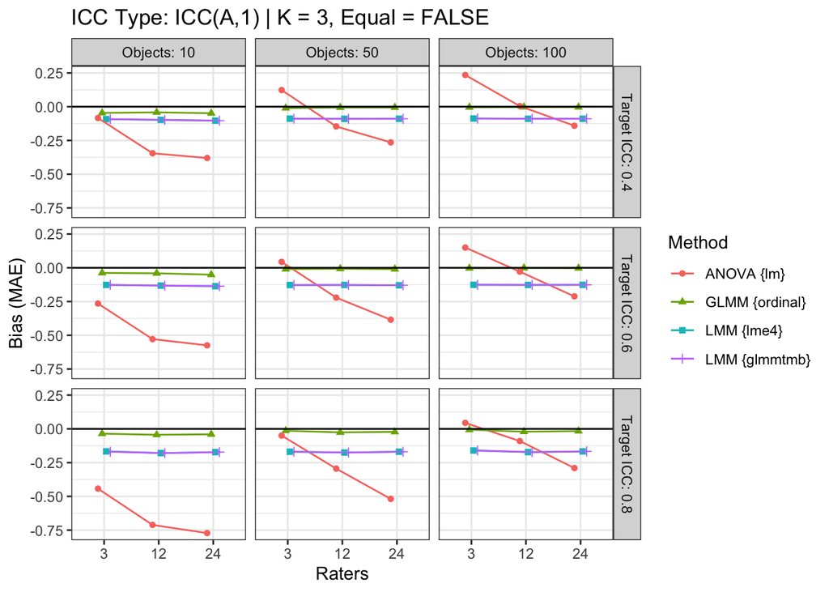

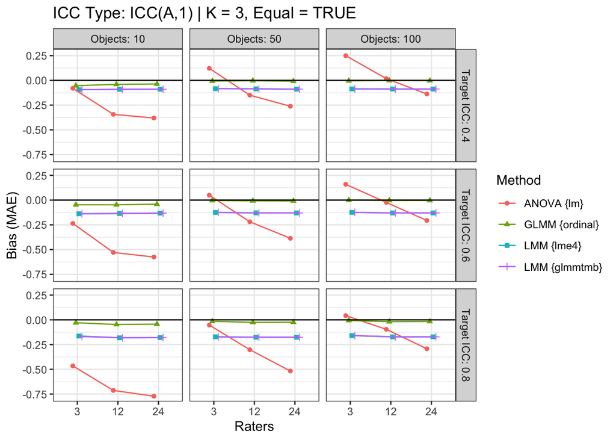

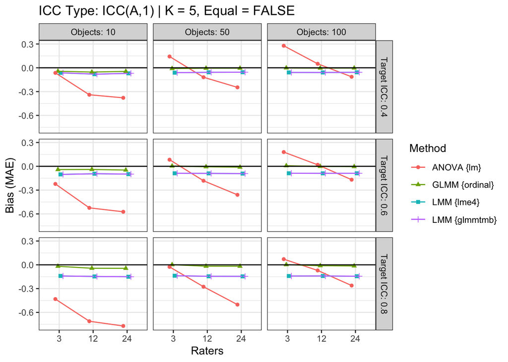

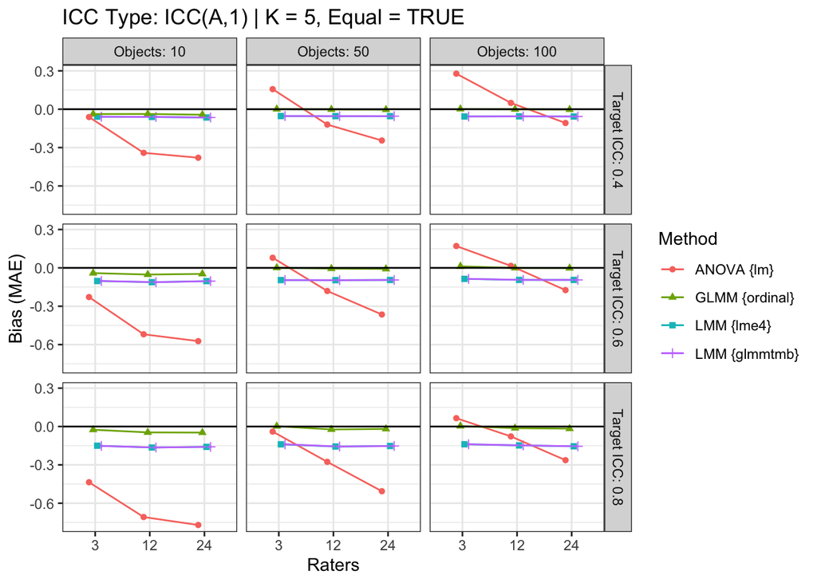

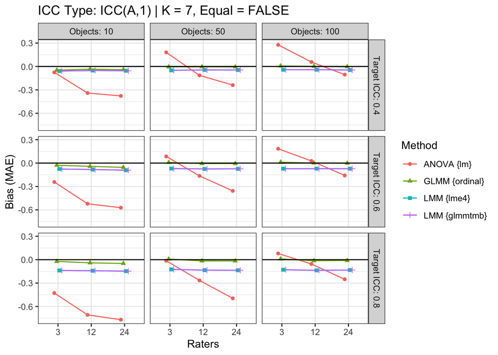

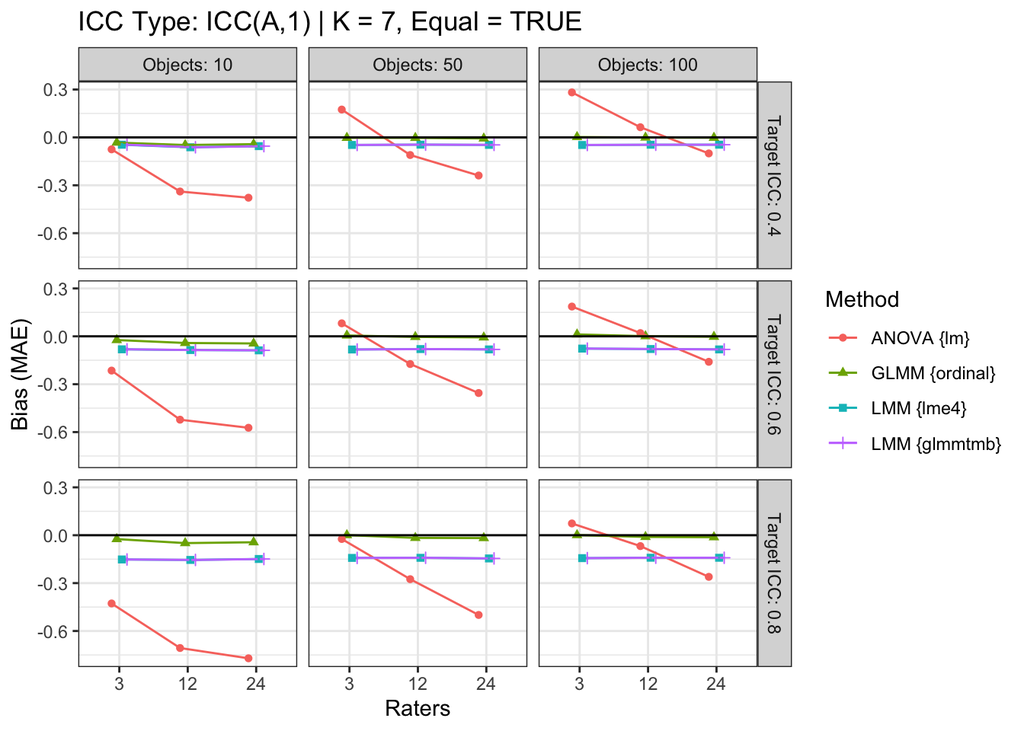

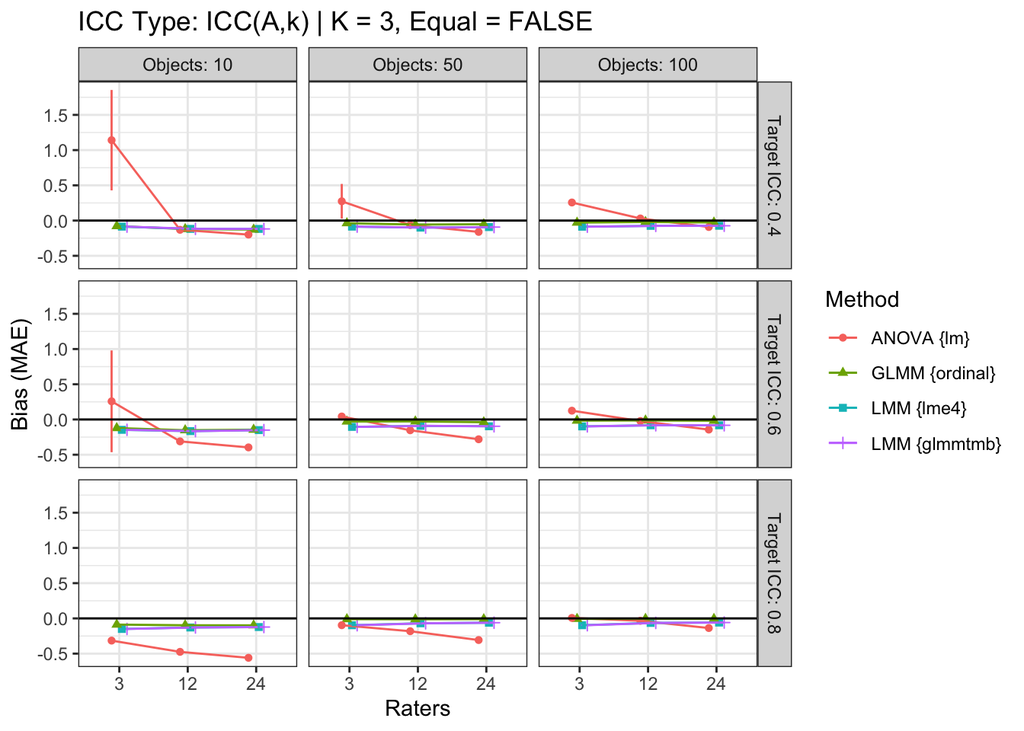

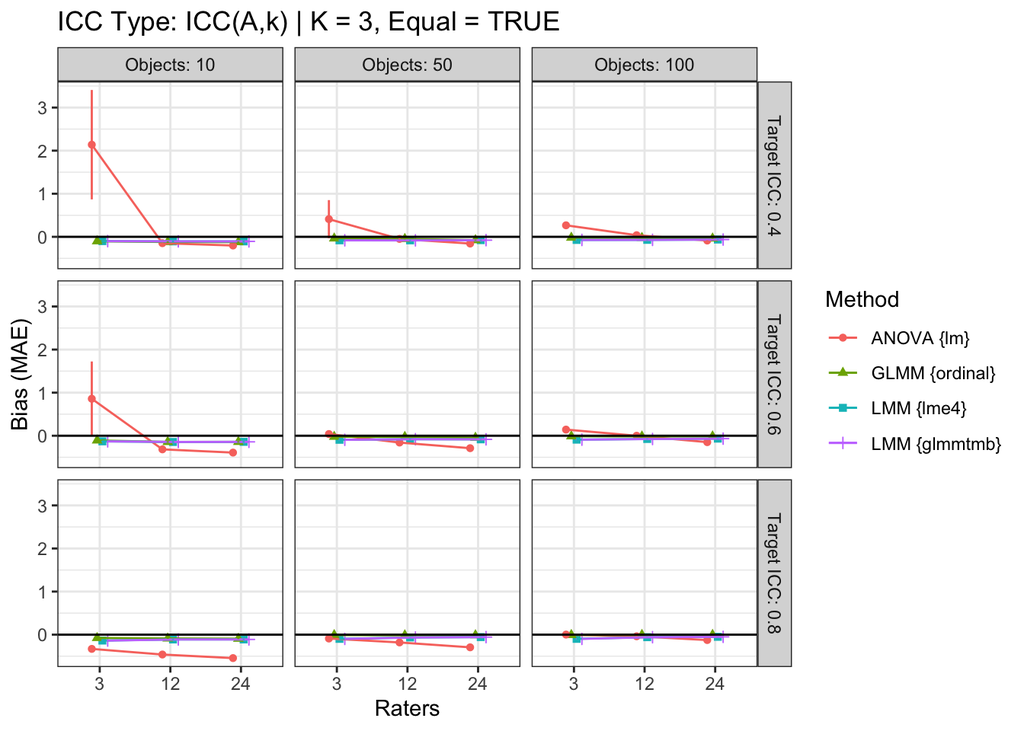

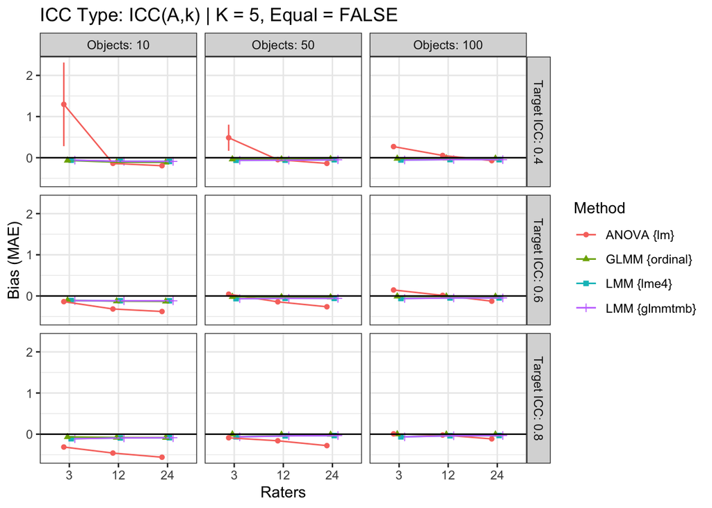

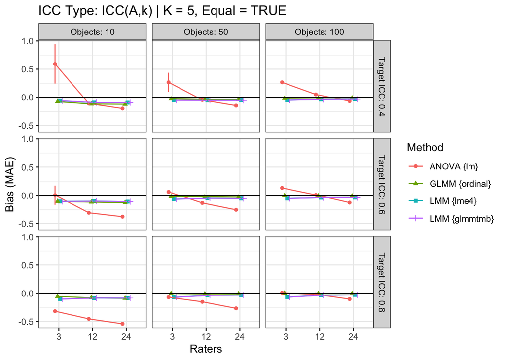

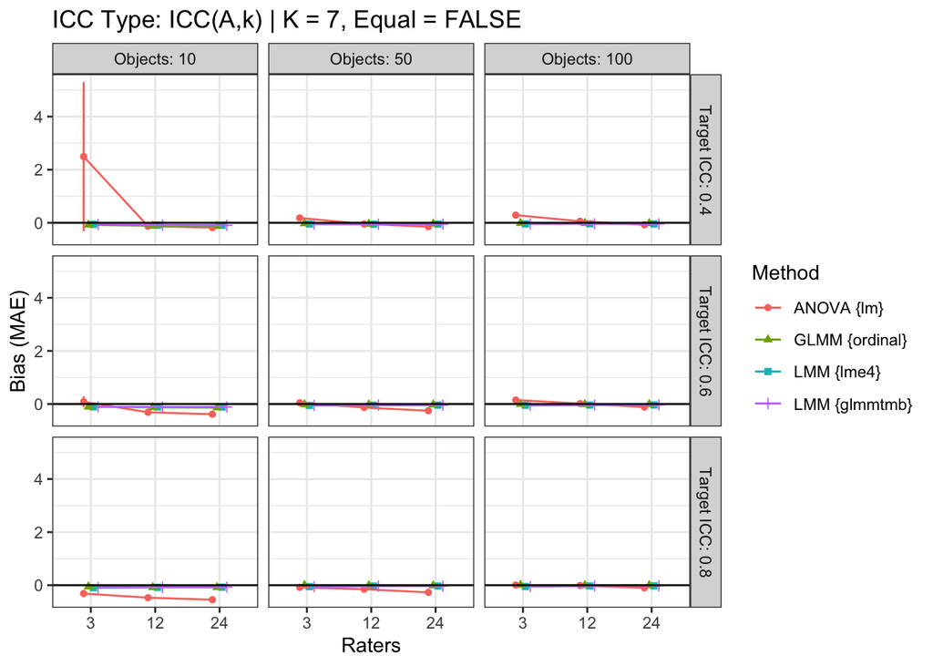

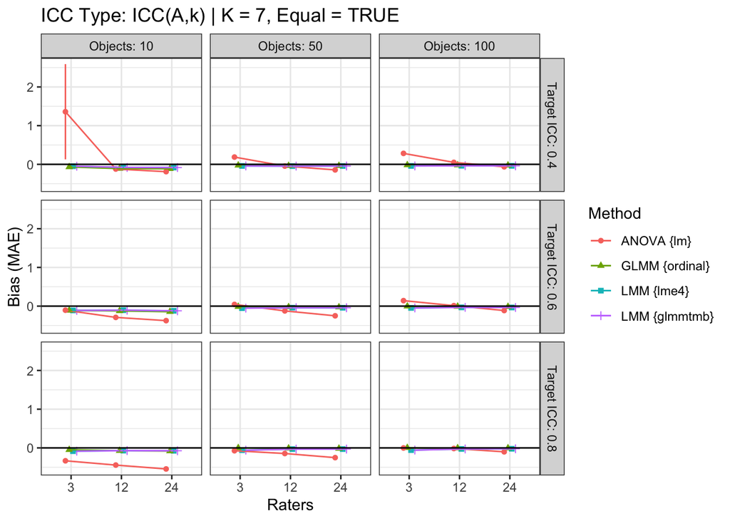

[12 more figures not shown]

```r
mae_plots <- bias |>
  group_by(icc, k_category, e_category) |>
  group_split() |>
  # 2. Map over the split data
  map(~ {
    # Extract values for a dynamic and descriptive title
    icc_val <- unique(.x$icc)
    k_val   <- unique(.x$k_category)
    e_val   <- unique(.x$e_category)

    # Generate the plot using your generalized function
    plot_simulation_bias(
      data = .x,
      x_var = n_raters,
      y_var = bias,
      col_var = Method,
      facet_row = `Target ICC`,
      facet_col = Objects,
      my_geoms = my_geom,
      plot_labs = plot_labels,
      title = paste0("ICC Type: ", icc_val, " | K = ", k_val, ", Equal = ", e_val)
    )
  })

mae_plots
```

### MAE Boxplots

Boxplots

```r
plot_icc_boxplots <- function(data, icc_label) {
  ggplot(data, aes(x = factor(k_category), y = bias, fill = Method)) +
    # Draw boxplots for each method side-by-side
    geom_boxplot(outliers = FALSE, outlier.size = 0.5, alpha = 0.7, outlier.shape = NA) +
    # Grid by Equality and Number of Objects
    facet_grid(`Category Equality` ~ Objects, labeller = label_both) +
    labs(
      title = paste("Bias Analysis for ICC Type:", icc_label),
      x = "Number of Categories (K)",
      y = "Bias (MAE)",
      fill = "Estimation Method"
    ) +
    theme_bw() +
    theme(legend.position = "bottom")
}

mae_boxplots <- bias %>%
  group_by(icc) %>%
  group_split() %>%
  map(~ {
    icc_val <- unique(.x$icc)

    plot_icc_boxplots(
      data = .x,
      icc_label = icc_val
    )
  })
```

```r
# # Walk through the plots and save them in organized subdirectories
# walk(all_boxplots, ~ {
#   # Pull the metadata from the individual plot's data
#   this_data <- .x$data
#   icc_dir <- as.character(unique(this_data$icc))

#   # Create directory if it doesn't exist
#   if (!dir.exists(icc_dir)) dir.create(icc_dir)

#   # file_name <- paste0(icc_dir, "/K", unique(this_data$k_category),
#   #                     "_E", unique(this_data$e_category), ".png")
#     file_name <- paste0(icc_dir, "/Boxplot_", unique(this_data$icc),
#                        ".png")

#   ggsave(file_name, plot = .x, width = 12, height = 9)
# })
```

### MAE Aggregated plots

Average over factors

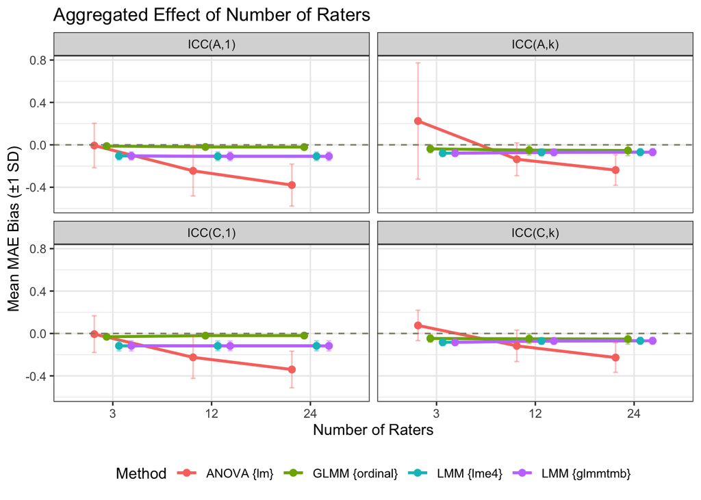

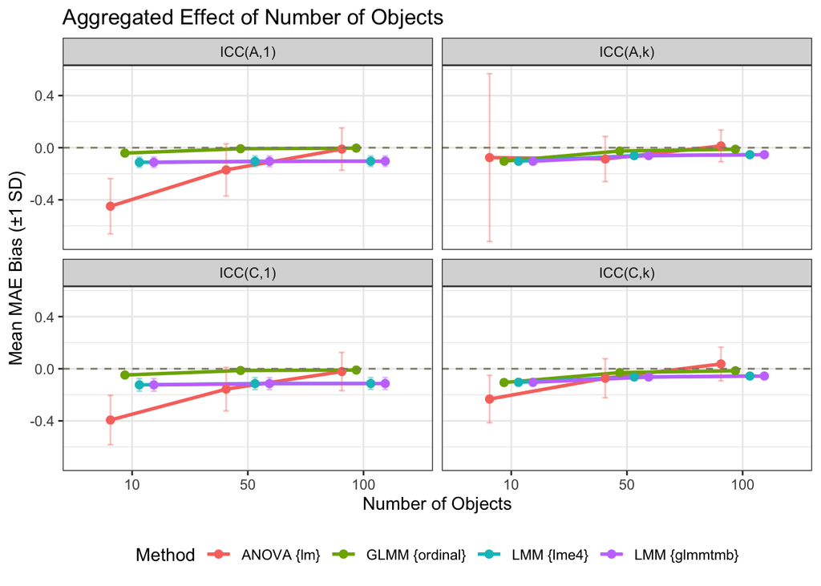

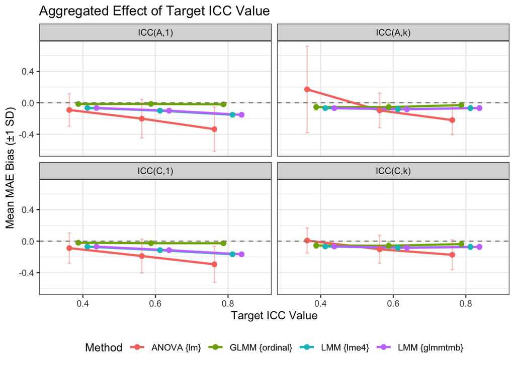

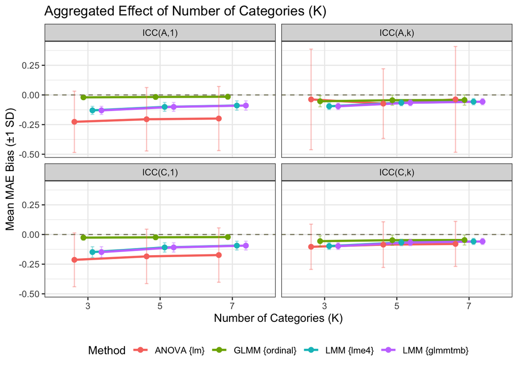

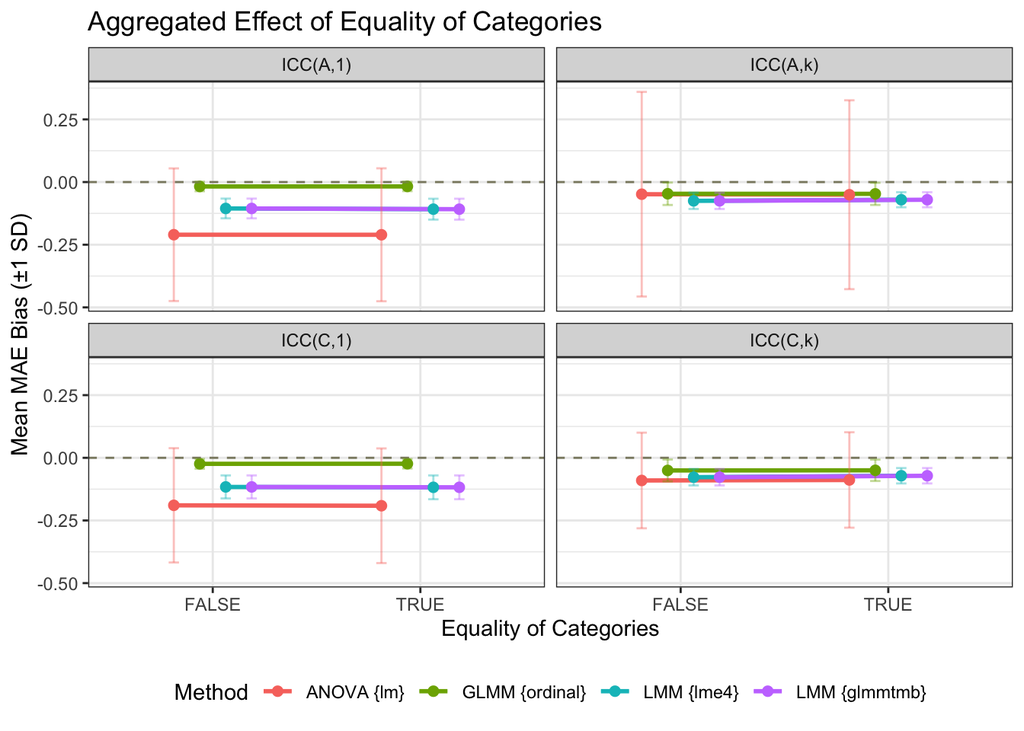

```r
 factors_to_test <- c("n_raters", "n_objects", "target_icc", "k_category", "e_category")

#  plot
 mae_aggregate_plots <- map(set_names(factors_to_test),
 ~ {plot_aggregated_facet(bias, .x, bias, 1)
 })
 mae_aggregate_plots
```

Save aggregated plots

```r
# # Define the output directory
# output_dir <- "~/Documents/Github/MastersThesis/iccs/aggregated_plots"

# # Create the folder if it doesn't already exist
# if (!dir.exists(output_dir)) {
#   dir.create(output_dir)
# }

# # 4. Save each plot using iwalk (iteration with names)
# iwalk(final_agg_plots, function(p, factor_name) {

#   # Construct a clean filename
#   file_name <- file.path(output_dir, paste0("summary_", factor_name, ".png"))

#   # Save with high resolution (300 DPI) for clarity
#   ggsave(
#     filename = file_name,
#     plot = p,
#     width = 12,    # Wider to accommodate multiple ICC facets
#     height = 8,
#     units = "in",
#     dpi = 300
#   )

#   message(paste("Saved:", file_name))
# })
```

## 3.2 Bias (Muthen & Muthen)

- Here, if bias is less than 10% then it is good

### Muthen & Muthen Individual Plots

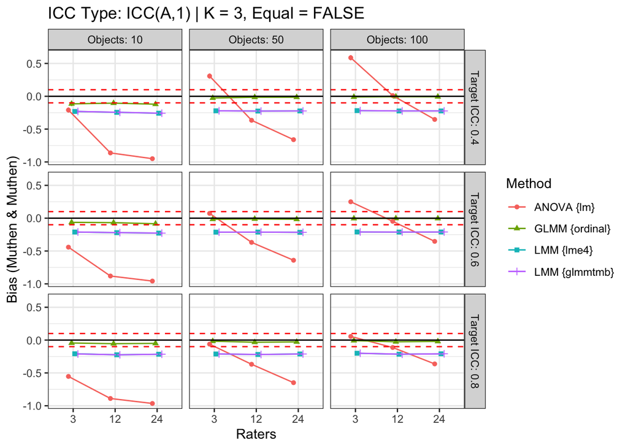

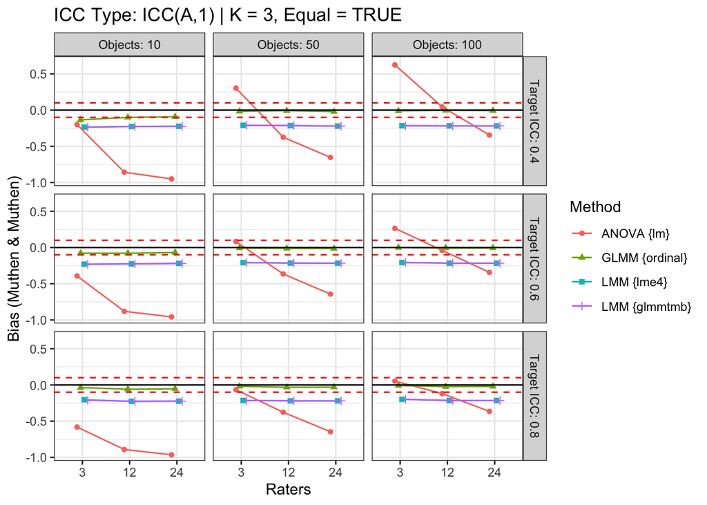

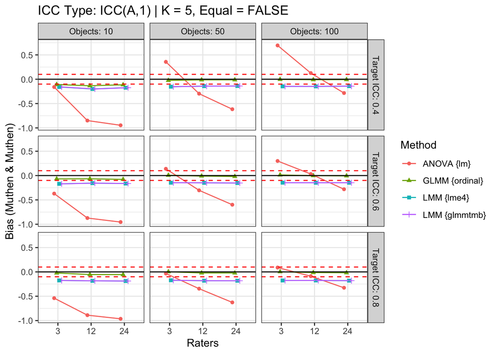

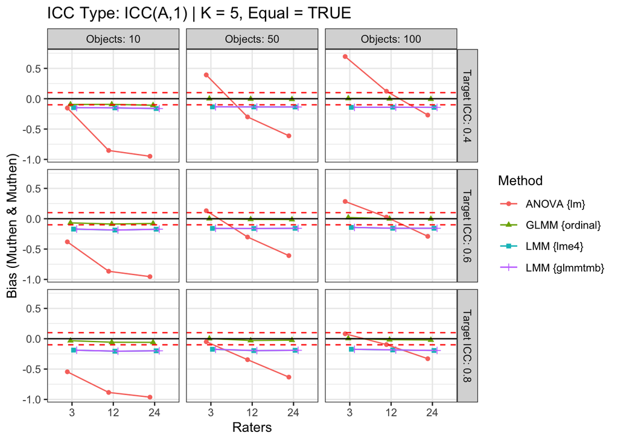

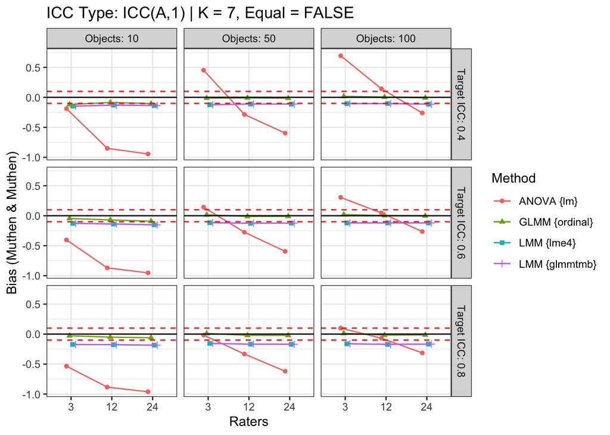

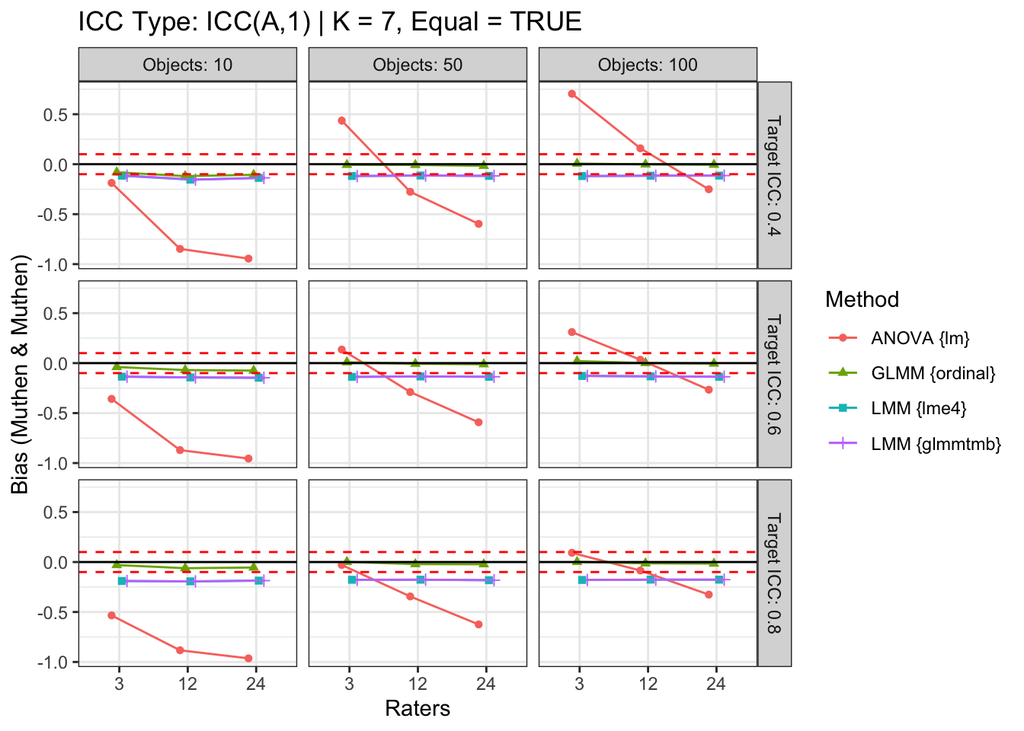

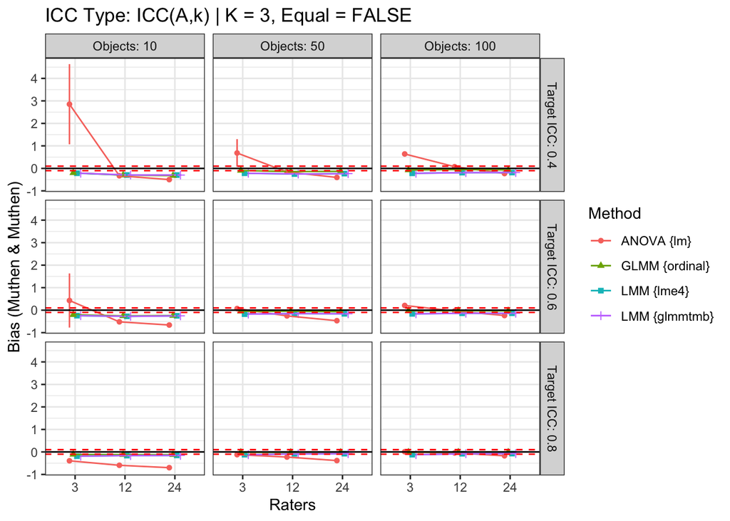

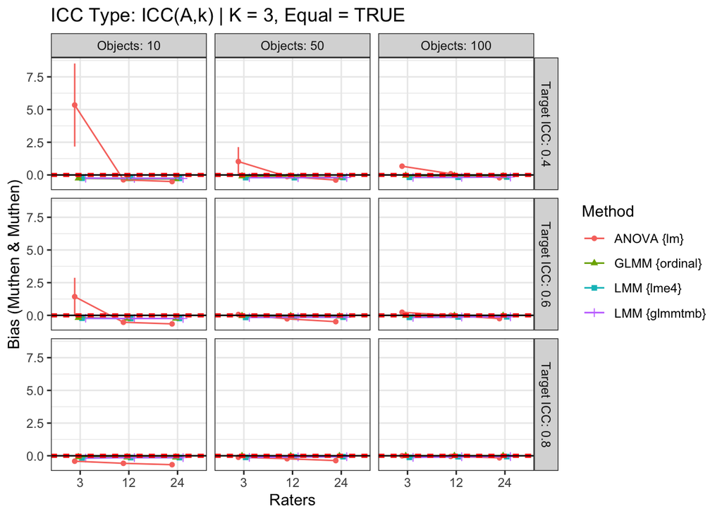

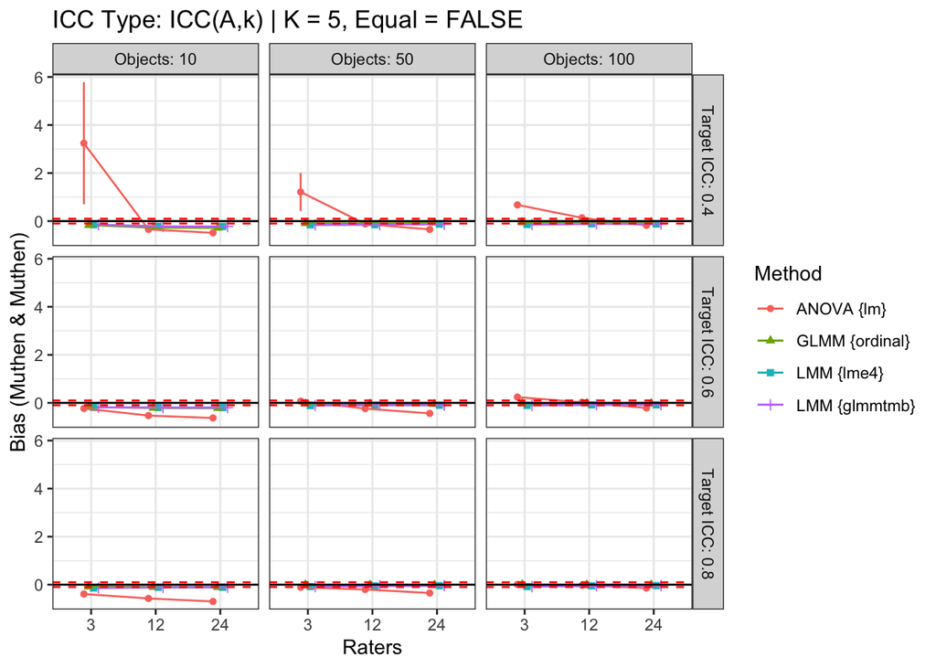

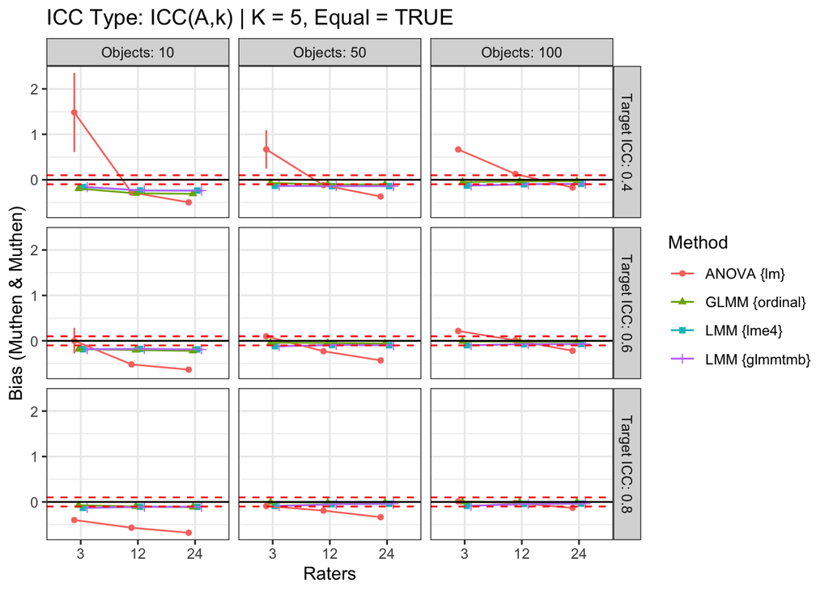

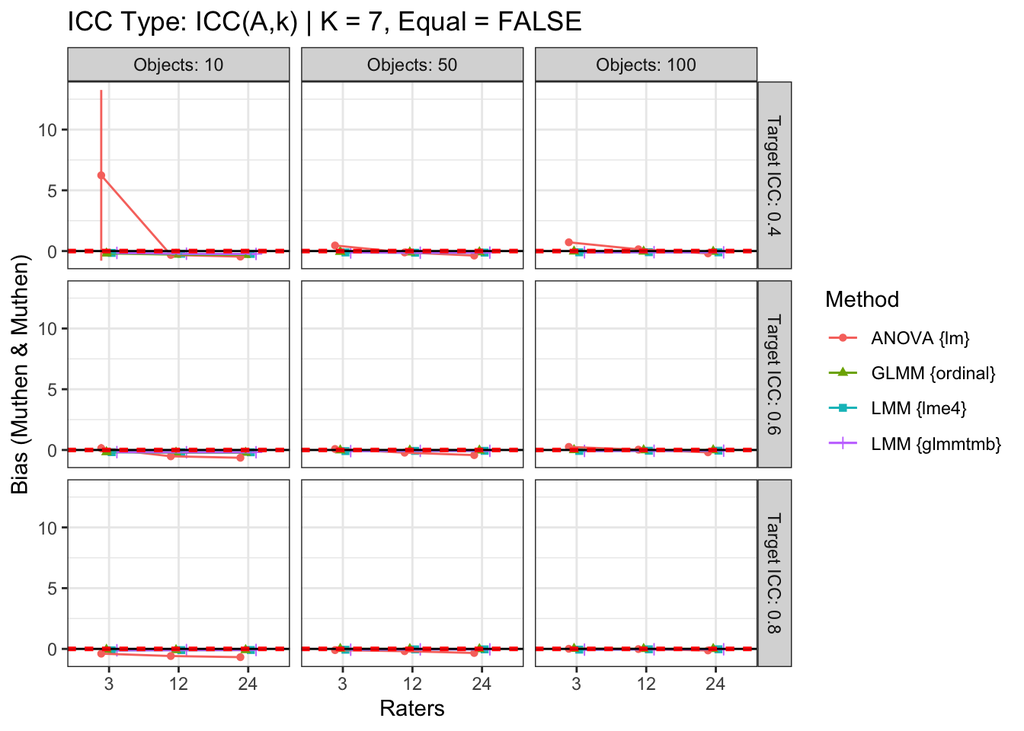

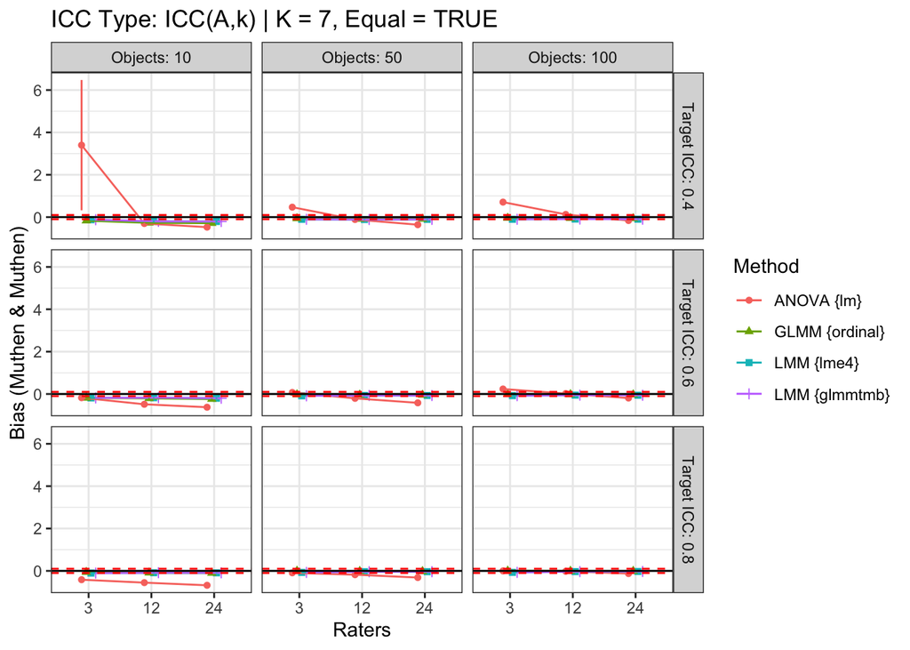

[12 more figures not shown]

```r
mm_labs <- c(
  n_raters = "Raters",
  n_objects = "Objects",
  target_icc = "Target ICC",
  n_category = "Category",
  bias = "Bias (Muthen & Muthen)"
)

mm_plots <- bias |>
  group_by(icc, k_category, e_category) |>
  group_split() |>
  # 2. Map over the split data
  map(~ {
    # Extract values for a dynamic and descriptive title
    icc_val <- unique(.x$icc)
    k_val   <- unique(.x$k_category)
    e_val   <- unique(.x$e_category)

    # Generate the plot using your generalized function
    plot_simulation_bias(
      data = .x,
      x_var = n_raters,
      y_var = bias2,
      col_var = Method,
      facet_row = `Target ICC`,
      facet_col = Objects,
      my_geoms = my_geom2,
      plot_labs = mm_labs,
      title = paste0("ICC Type: ", icc_val, " | K = ", k_val, ", Equal = ", e_val)
    )
  })



mm_plots
```